# ps3

## Problem 1: Some Cool Ridge and LASSO Identities (30 pts.)

### Part 1 (10 pts.)

Both ridge regression and the LASSO are approaches that add penalty terms to the standard mean squared error loss function that discourage solutions that are too dense - we'd rather have a biased estimate of the regression coefficients that then leads to lower expected prediction error by virtue of reduced between model variance. Both the ridge and LASSO solutions arise due to almost ad-hoc solutions to the problem of collinearity and/or pursuit of a method for solving the $L_0$ best-subset regression problem. However, there is an equally useful equivalent justification via Bayesian statistics.

Recall that the likelihood for the general linear regression problem assumes normal idiosyncratic errors:

$$\ell(\boldsymbol{y} \mid \boldsymbol{X} , \boldsymbol{\beta} , \sigma^2) = \prod \limits_{i = 1}^N \frac{1}{\sqrt{2 \pi \sigma^2}} \exp \left[- \frac{1}{2 \sigma^2} (y_i - \boldsymbol{x}_i'\boldsymbol{\beta})^2 \right]$$

and admits a workable log-likelihood:

$$\ell \ell (\boldsymbol{y} \mid \boldsymbol{X} , \boldsymbol{\beta} , \sigma^2) = -\frac{N}{2} \log 2 \pi \sigma^2 - \frac{1}{2 \sigma^2} \|\boldsymbol y - \boldsymbol{X \beta} \|^2$$

The Bayesian approach places a **prior** on the unknown parameters and characterizes a **posterior distribution** that combines our prior uncertainty about the value of the unknown parameters with uncertainty due to sampling error (e.g. the prior and the likelihood).

Bayes' theorem tells us that the log posterior distribution on $\boldsymbol \beta$ taking $\sigma^2$ as known is proportional to ($\propto$):

$$\log f(\boldsymbol \beta | \boldsymbol X , \boldsymbol y, \sigma^2) \propto \ell \ell (\boldsymbol{y} \mid \boldsymbol{X} , \boldsymbol{\beta} , \sigma^2) + \log f(\boldsymbol \beta)$$

where $\log f(\boldsymbol \beta)$ is the **log prior**. Then, the point estimate of $\boldsymbol \beta$ that minimizes the loss is the one that **maximizes** the posterior - the posterior mode.

Suppose we define the prior over $\boldsymbol \beta$ as the product of independent normal distributions with common mean 0 and variance $\tau^2$:

$$ f(\boldsymbol{\beta}) = \prod \limits_{j = 1}^P \mathcal{N}(\beta_j \mid 0 , \tau^2) = \prod \limits_{j = 1}^P \frac{1}{\sqrt{2 \pi \tau^2}} \exp \left[-\frac{1}{2 \tau^2} \beta_j^2 \right]$$

Show that the negative log posterior distribution on $\boldsymbol \beta$ is proportional to the ridge regression loss function:

$$\| \boldsymbol y - \boldsymbol{X\beta} \|^2 + \lambda \sum \limits_{j = 1}^P \beta^2_j$$

and find an expression for the regularization constant, $\lambda$ that is a function of known quantities.

#### Answer

We want to show $\text{Loss}_{\text{ridge}} = \| \boldsymbol{y-X\beta} \|_2^2 + \lambda \|\boldsymbol{\beta_j}\|_2^2 \propto -\log f(\boldsymbol{\beta}|\boldsymbol{X , y} , \sigma^2)$

Because $\log f(\boldsymbol{\beta}|\boldsymbol{X, y}, \sigma^2) \propto \ell \ell(\boldsymbol{y \mid X, \beta}, \sigma^2) + \log f(\boldsymbol{\beta})$, we need to show $$ \text{Loss}_{\text{ridge}} = \left( \| \boldsymbol{y-X\beta} \|_2^2 + \lambda \|\boldsymbol{\beta_j}\|_2^2 \right) \propto -\left[ \ell \ell(\boldsymbol{y \mid X, \beta}, \sigma^2) + \log f(\boldsymbol{\beta}) \right] $$

Consider the log prior, $$ \begin{align*} \log f(\boldsymbol{\beta}) &= \log \left(\prod \limits_{j = 1}^P \frac{1}{\sqrt{2 \pi \tau^2}} \exp \left[-\frac{1}{2 \tau^2} \beta_j^2 \right]\right) \\ &= \sum\limits_{j=1}^P\log \frac{\exp \left[-\frac{1}{2 \tau^2} \beta_j^2 \right]}{\sqrt{2\pi \tau^2}} \\ &= \sum\limits_{j=1}^P \left(-\frac{\beta_j^2}{2\tau^2} - \log\left[2\pi \tau^2\right]^{1/2}\right) \\ &= \sum\limits_{j=1}^P \left(-\frac{\beta_j^2}{2\tau^2} - \frac{1}{2} \log[2\pi\tau^2]\right) \\ &= -\frac{P}{2} \log (2\pi \tau^2) - \frac{1}{2\tau^2} \sum\limits_{j=1}^P \beta_j^2 \end{align*} $$ Then, the log posterior on $\beta$ is proportional to $$ \begin{align*} \log f(\boldsymbol{\beta}|\boldsymbol{X, y}, \sigma^2) &\propto \ell \ell(\boldsymbol{y \mid X, \beta}, \sigma^2) + \log f(\boldsymbol{\beta})\\ &\propto -\frac{N}{2} \log 2 \pi \sigma^2 - \frac{1}{2 \sigma^2} \|\boldsymbol y - \boldsymbol{X \beta} \|^2 - \frac{P}{2} \log (2\pi \tau^2) - \frac{1}{2\tau^2} \sum\limits_{j=1}^P \beta_j^2 \\ &\propto - \frac{1}{2 \sigma^2} \|\boldsymbol y - \boldsymbol{X \beta} \|^2 - \frac{1}{2\tau^2} \sum\limits_{j=1}^P \beta_j^2 \\ -\log f(\boldsymbol{\beta}|\boldsymbol{X, y}, \sigma^2)&\propto \frac{1}{2 \sigma^2} \|\boldsymbol y - \boldsymbol{X \beta} \|^2 + \frac{1}{2\tau^2} \sum\limits_{j=1}^P \beta_j^2 \end{align*} $$ To find $\lambda$, we construct $$ \begin{align*} \text{Loss}_{\text{ridge}} = \| \boldsymbol{y-X\beta} \|_2^2 + \lambda \|\boldsymbol{\beta_j}\|_2^2 &\propto \frac{1}{2 \sigma^2} \|\boldsymbol y - \boldsymbol{X \beta} \|^2 + \frac{1}{2\tau^2} \sum\limits_{j=1}^P \beta_j^2 \\ &\propto \|\boldsymbol y - \boldsymbol{X \beta} \|^2 + \frac{\sigma^2}{\tau^2} \|\boldsymbol{\beta_j}\|_2^2 \end{align*} $$ Therefore, we can see that the regularization parameter for ridge regression is $\lambda = \frac{\sigma^2}{\tau^2}$

### Part 2 (10 pts.)

There's nothing saying that our prior on each $\beta_j$ needs to be normal. In fact, we can choose other priors for a variety of different reasons. Another viable choice of prior on $\beta_j$ is the [Laplace distribution](https://en.wikipedia.org/wiki/Laplace_distribution) with mean 0 and scale parameter $b > 0$:

$$f(\boldsymbol \beta) = \prod \limits_{j = 1}^P \frac{1}{2b} \exp \left[- \frac{|\beta_j|}{b} \right]$$

The variance of a Laplace distributed random variable is $2b^2$ - so it scales similarly to variance in the normal distribution.

Show that the negative log posterior distribution on $\boldsymbol \beta$ using Laplace priors is proportional to the LASSO loss function:

$$\frac{1}{2}\| \boldsymbol y - \boldsymbol{X\beta} \|^2 + \lambda \sum \limits_{j = 1}^P | \beta_j |$$

and find an expression for the regularization constant, $\lambda$ that is a function of known quantities.

#### Answer

We want to show $\text{Loss}_{\text{lasso}} = \frac{1}{2}\| \boldsymbol{y-X\beta} \|_2^2 + \lambda \|\boldsymbol{\beta_j}\|_1 \propto -\log f(\boldsymbol{\beta}|\boldsymbol{X , y} , \sigma^2)$

Because $\log f(\boldsymbol{\beta}|\boldsymbol{X, y}, \sigma^2) \propto \ell \ell(\boldsymbol{y \mid X, \beta}, \sigma^2) + \log f(\boldsymbol{\beta})$, we need to show $$ \text{Loss}_{\text{lasso}} = \left( \frac{1}{2} \| \boldsymbol{y-X\beta} \|_2^2 + \lambda \|\boldsymbol{\beta_j}\|_1 \right) \propto -\left[ \ell \ell(\boldsymbol{y \mid X, \beta}, \sigma^2) + \log f(\boldsymbol{\beta}) \right] $$

Consider the log prior, $$ \begin{align*} \log f(\boldsymbol{\beta}) &= \log \left(\prod \limits_{j = 1}^P \frac{1}{2 b} \exp \left[-\frac{\mid \beta_j \mid}{b}\right]\right) \\ &= \sum\limits_{j=1}^P\log \frac{ \exp \left[-\frac{\mid \beta_j \mid}{b}\right]}{2b} \\ &= \sum\limits_{j=1}^P \left(-\frac{\mid \beta_j \mid}{b} - \log(2b)\right) \\ &= -P\log(2b) - \frac{1}{b}\sum\limits_{j=1}^P \mid \beta_j \mid \end{align*} $$ Then, the log posterior on $\beta$ is proportional to $$ \begin{align*} \log f(\boldsymbol{\beta}|\boldsymbol{X, y}, \sigma^2) &\propto \ell \ell(\boldsymbol{y \mid X, \beta}, \sigma^2) + \log f(\boldsymbol{\beta})\\ &\propto -\frac{N}{2} \log 2 \pi \sigma^2 - \frac{1}{2 \sigma^2} \|\boldsymbol y - \boldsymbol{X \beta} \|^2 -P\log(2b) - \frac{1}{b}\sum\limits_{j=1}^P \mid \beta_j \mid \\ &\propto - \frac{1}{2 \sigma^2} \|\boldsymbol y - \boldsymbol{X \beta} \|^2 - \frac{1}{b}\sum\limits_{j=1}^P \mid \beta_j \mid \\ -\log f(\boldsymbol{\beta}|\boldsymbol{X, y}, \sigma^2)&\propto \frac{1}{2 \sigma^2} \|\boldsymbol y - \boldsymbol{X \beta} \|^2 + \frac{1}{b}\sum\limits_{j=1}^P \mid \beta_j\mid \end{align*} $$ To find $\lambda$, we construct $$ \begin{align*} \text{Loss}_{\text{lasso}} = \left( \frac{1}{2} \| \boldsymbol{y-X\beta} \|_2^2 + \lambda \|\boldsymbol{\beta_j}\|_1 \right) &\propto \frac{1}{2 \sigma^2} \|\boldsymbol y - \boldsymbol{X \beta} \|^2 + \frac{1}{b}\sum\limits_{j=1}^P \mid \beta_j\mid\\ &\propto \frac{1}{2} \|\boldsymbol y - \boldsymbol{X \beta} \|_2^2 + \frac{\sigma^2}{b} \|\boldsymbol{\beta_j}\|_1 \end{align*} $$ Therefore, we can see that the regularization parameter for LASSO regression is $\lambda = \frac{\sigma^2}{b}$

### Part 3 (10 pts.)

There is a relationship between the optimal solutions for the regression coefficients under no penalty (the OLS solution), the ridge penalty, and the LASSO penalty. The exact relationship cannot be derived for most cases, but we can gain some knowledge by assuming that the predictors are exactly orthogonal to one another. Since we can always rescale the variance of the features, we can further restrict this to feature sets that have **orthonormal** columns - $\boldsymbol{X'X} = \mathcal{I}_P$.

Assuming the feature matrix, $\boldsymbol{X}$, has orthnormal columns, show that:

$$\hat{\beta}_{OLS} = \boldsymbol{X'y} \text{ ; } \hat{\beta}_{Ridge} = \frac{\hat{\beta}_{OLS}}{1 + \lambda} \text{ ; } \hat{\beta}_{LASSO} = \text{sign}(\hat{\beta}_{OLS}) \times \text{max}(|\hat{\beta}_{OLS}| - \lambda , 0)$$

What do these equations show about **how** ridge and LASSO shrink coefficients towards zero? Why can the LASSO set a coefficient to zero while ridge cannot?

#### Answer

Given the feature matrix, $\boldsymbol{X}$, is a orthogonal matrix, then $\boldsymbol{X}^\top = \boldsymbol{X}^{-1}$ and $\boldsymbol{X^\top X} = \mathcal{I}_P$, where $P$ denotes the number of regression coefficients.

1. Consider the base OLS case:

   The normal equation of OLS (derived in ps2), $\boldsymbol{X^\top X\beta} = \boldsymbol{\beta^\top y}$

   Therefore, the OLS solution is $$ \begin{align*} \hat \beta &= \boldsymbol{(X^\top X)^{-1}} \boldsymbol{X^\top y} \\ &= (\mathcal{I}_P)^{-1} \boldsymbol{X^\top y} \\ &= \boldsymbol{X^\top y} \end{align*} $$
2. Ridge Regression $$\underset{\boldsymbol{\beta}^*}{\text{argmin}} \quad \|\boldsymbol{y-X\beta}\|_2^2 + \lambda \|\boldsymbol{\beta}\|^2_2$$

   Consider the above objective function, $$ \begin{align*} \|\boldsymbol{y-X\beta}\|_2^2 + \lambda \|\boldsymbol{\beta}\|^2_2 &= \|\boldsymbol{y-X\beta}\|_2^2 + \left\|\sqrt{\lambda} \boldsymbol{\beta}\right\|^2_2 \\ &=\|\boldsymbol{y-X\beta}\|_2^2 + \left\|0 - \sqrt{\lambda} \boldsymbol{\beta}\right\|^2_2 \\ &=\left\|\begin{pmatrix} \boldsymbol{y - X\beta}\\ \boldsymbol{0}-\sqrt{\lambda}\boldsymbol{\beta} \end{pmatrix}\right\|^2_2 \\ &=\left\|\begin{pmatrix} \boldsymbol{y} \\ \boldsymbol{0} \end{pmatrix} - \begin{pmatrix}\boldsymbol{X} \\ \sqrt{\lambda} \mathcal{I}_P \end{pmatrix} \boldsymbol{\beta}\right\|_2^2 \end{align*} $$ This can be viewed as a OLS problem with $\boldsymbol{y^*} \in \mathbb{R}^{N+P}$ and $\boldsymbol{X}^* \in \mathbb{R}^{(N+P)\times P}$, so we can use the normal equation to derive the solution:

   $$ \begin{align*} (\boldsymbol{X}^\top \boldsymbol{X} + \lambda \mathcal{I}_P)\boldsymbol{\beta} &= \boldsymbol{X}^\top \boldsymbol{y} \\\\ \boldsymbol{\hat \beta} &= (\boldsymbol{X}^\top \boldsymbol{X} + \lambda \mathcal{I}_P)^{-1}\boldsymbol{X}^\top \boldsymbol{y} \\ &=((1+\lambda)\mathcal{I}_P)^{-1}\boldsymbol{X}^\top\boldsymbol{y} \\ &= (1+\lambda)^{-1} \mathcal{I}_P \boldsymbol{X}^\top \boldsymbol{y}\\ &=\frac{\boldsymbol{X}^\top \boldsymbol{y}}{1+\lambda} \end{align*} $$
3. LASSO Regression $$\underset{\boldsymbol{\beta}^*}{\text{argmin}} \quad \frac{1}{2}\|\boldsymbol{y-X\beta}\|_2^2 + \lambda \|\boldsymbol{\beta}\|_1$$

   Consider the above objective function, $$ \begin{align*} \frac{1}{2}\|\boldsymbol{y-X\beta}\|_2^2 + \lambda \|\boldsymbol{\beta}\|_1 &= \frac{1}{2} (\boldsymbol{y}^\top - \boldsymbol{\beta}^\top \boldsymbol{X}^\top)(\boldsymbol{y}-\boldsymbol{X}\boldsymbol{\beta}) + \lambda \|\boldsymbol{\beta}\|_1 \\ &= \frac{1}{2}(\boldsymbol{y}^\top\boldsymbol{y} - \boldsymbol{y}^\top \boldsymbol{X}\boldsymbol{\beta} - \boldsymbol{\beta^\top X^\top y} + \boldsymbol{\beta^\top X^\top X \beta}) + \lambda \|\boldsymbol{\beta}\|_1\\ &= \frac{1}{2}(\boldsymbol{y}^\top\boldsymbol{y} - (\boldsymbol{\beta^\top X^\top y})^{-1} - \boldsymbol{\beta^\top X^\top y} + \boldsymbol{\beta^\top X^\top X \beta}) + \lambda \|\boldsymbol{\beta}\|_1 \\ &= \frac{1}{2}(\boldsymbol{y}^\top\boldsymbol{y} - (\boldsymbol{\beta^\top \hat\beta_{OLS}})^{-1} - \boldsymbol{\beta^\top \hat\beta_{OLS}} + \boldsymbol{\beta^\top X^\top X \beta}) + \lambda \|\boldsymbol{\beta}\|_1 \\ &= \frac{1}{2}(\boldsymbol{y}^\top\boldsymbol{y}) - \boldsymbol{\beta^\top \hat\beta_{OLS}} + \frac{1}{2}\boldsymbol{\beta^\top \beta} + \lambda \|\boldsymbol{\beta}\|_1 \end{align*} $$

   Therefore, by getting rid of the constant, we can update our objective regression as the following $$\underset{\boldsymbol{\beta}^*}{\text{argmin}} \quad - \boldsymbol{\beta^\top \hat\beta_{OLS}} + \frac{1}{2}\boldsymbol{\beta^\top \beta} + \lambda \|\boldsymbol{\beta}\|_1$$

   Consider the element-wise representation of the objective function, $$ \sum\limits_{j=1}^P -\beta_j \hat\beta^{OLS}_j + \frac{1}{2}\beta_j^2 + \lambda |\beta_j| $$ We can solve the problem by minimizing the function for each $j$, $g_j(\beta_j) = -\beta_j \hat\beta^{OLS}_j + \frac{1}{2}\beta_j^2 + \lambda |\beta_j|$
   - When $\beta_j < 0$, the objective function for the $j$ th parameter becomes $$ g_j(\beta_j) = -\beta_j \hat\beta^{OLS}_j + \frac{1}{2}\beta_j^2 - \lambda \beta_j \\ \frac{\partial}{\partial \beta_j} g_j(\beta_j) = -\hat\beta^{OLS}_j + \beta_j -\lambda = 0 $$ $$ \begin{align*} -\hat\beta^{OLS}_j + \beta_j -\lambda &= 0 \\ \hat\beta_j &= \lambda + \hat\beta^{OLS}_j \end{align*} $$
   - When $\beta_j > 0$, the objective function for the $j$ th parameter becomes $$ g_j(\beta_j) = -\beta_j \hat\beta^{OLS}_j + \frac{1}{2}\beta_j^2 + \lambda \beta_j \\ \frac{\partial}{\partial \beta_j} g_j(\beta_j) = -\hat\beta^{OLS}_j + \beta_j +\lambda = 0 $$ $$ \begin{align*} -\hat\beta^{OLS}_j + \beta_j +\lambda &= 0 \\ \hat\beta_j &= \hat\beta^{OLS}_j - \lambda \end{align*} $$
   - When $\beta_j = 0$, $g_j(\beta_j) = 0$

     Therefore, $$\hat{\beta}_{LASSO} = \text{sign}(\hat{\beta}_{OLS}) \times \text{max}(|\hat{\beta}_{OLS}| - \lambda , 0)$$

## Data Prep

```python
import pandas as pd
import numpy as np
import matplotlib.pyplot as plt
import statsmodels.api as sm
```

```python
train_df = pd.read_csv("office_train.csv")
train_df
```

|  | season | episode | episode_name | andy | angela | darryl | dwight | jim | kelly | kevin | ... | paul_lieberstein | mindy_kaling | paul_feig | gene_stupnitsky | jennifer_celotta | randall_einhorn | brent_forrester | jeffrey_blitz | justin_spitzer | imdb_rating |
| --- | --- | --- | --- | --- | --- | --- | --- | --- | --- | --- | --- | --- | --- | --- | --- | --- | --- | --- | --- | --- | --- |
| 0 | Season 1 | 1 | pilot | 0 | 1 | 0 | 29 | 36 | 0 | 1 | ... | 0 | 0 | 0 | 0 | 0 | 0 | 0 | 0 | 0 | 7.6 |
| 1 | Season 1 | 2 | diversity day | 0 | 4 | 0 | 17 | 25 | 2 | 8 | ... | 0 | 0 | 0 | 0 | 0 | 0 | 0 | 0 | 0 | 8.3 |
| 2 | Season 1 | 5 | basketball | 0 | 3 | 15 | 25 | 21 | 0 | 1 | ... | 0 | 0 | 0 | 0 | 0 | 0 | 0 | 0 | 0 | 8.4 |
| 3 | Season 1 | 6 | hot girl | 0 | 3 | 0 | 28 | 55 | 0 | 5 | ... | 0 | 1 | 0 | 0 | 0 | 0 | 0 | 0 | 0 | 7.8 |
| 4 | Season 2 | 2 | sexual harassment | 0 | 2 | 9 | 11 | 16 | 0 | 6 | ... | 0 | 0 | 0 | 0 | 0 | 0 | 0 | 0 | 0 | 8.2 |
| ... | ... | ... | ... | ... | ... | ... | ... | ... | ... | ... | ... | ... | ... | ... | ... | ... | ... | ... | ... | ... | ... |
| 110 | Season 9 | 4 | work bus | 43 | 5 | 11 | 40 | 60 | 0 | 17 | ... | 0 | 0 | 0 | 0 | 0 | 0 | 1 | 0 | 0 | 7.9 |
| 111 | Season 9 | 17 | farm | 5 | 8 | 1 | 51 | 6 | 0 | 12 | ... | 1 | 0 | 0 | 0 | 0 | 0 | 0 | 0 | 0 | 7.5 |
| 112 | Season 9 | 18 | promos | 11 | 32 | 12 | 37 | 31 | 0 | 9 | ... | 0 | 0 | 0 | 0 | 1 | 0 | 0 | 0 | 0 | 8.0 |
| 113 | Season 9 | 21 | livin dream | 68 | 30 | 11 | 54 | 63 | 0 | 13 | ... | 0 | 0 | 0 | 0 | 0 | 0 | 0 | 1 | 0 | 8.9 |
| 114 | Season 9 | 22 | aarm | 44 | 39 | 30 | 87 | 89 | 0 | 30 | ... | 0 | 0 | 0 | 0 | 0 | 0 | 1 | 0 | 0 | 9.3 |

115 rows × 31 columns

```python
train_df.columns
```

```
Index(['season', 'episode', 'episode_name', 'andy', 'angela', 'darryl',
       'dwight', 'jim', 'kelly', 'kevin', 'michael', 'oscar', 'pam', 'phyllis',
       'ryan', 'toby', 'erin', 'jan', 'ken_kwapis', 'greg_daniels',
       'b_j_novak', 'paul_lieberstein', 'mindy_kaling', 'paul_feig',
       'gene_stupnitsky', 'jennifer_celotta', 'randall_einhorn',
       'brent_forrester', 'jeffrey_blitz', 'justin_spitzer', 'imdb_rating'],
      dtype='object')
```

## Problem 2: Applying Ridge and LASSO

Ridge and LASSO are great methods for parsing through data sets with lots of predictors to find:

1. An interpretable set of important predictors - which predictors are **signal** and which ones are just **noise**
2. The set of parameters that minimize expected prediction error (with all the caveats that we discussed in the previous lectures)

Where these methods really shine for purpose 1 (and purpose 2, by construction) is when the ratio of predictors to observations approaches 1. To see this and work through an example using pre-built software, let's try to build a model that predicts IMDB ratings for episodes of the Office (the U.S. Version). `office_train.csv` includes IMDB ratings (`imdb_rating`) for 115 episodes of the office and a number of predictors for each episode:

1. The season of the episode (1 - 9, which should be treated as an unordered categorical variable)
2. The number of times main characters speak in the episode (`andy` through `jan`)
3. The director of the episode (`ken_kwapis` through `justin_spitzer`). There can be more than 1 director per episode, so it's not a pure categorical variable. However, the correlation is high!

Let's use this data to build a predictive model for IMDB ratings and check our predictive accuracy on the heldout test set (`office_test.csv`).

For this problem, you can restrict your search to the set of standard linear models (e.g. no interactions, no basis expansions, etc.). If you would like to try to include more terms to improve the model, you are more than welcome to try!

### Part 1 (10 pts.)

Start by limiting yourself to the standard OLS model.

Find the regression coefficients that minimize the training error under squared error loss and use this model to compute the LOOCV estimate of the expected prediction error.

Which predictors are important? Which ones are not? This can be difficult to tell from the OLS estimates!

```python
# OLS
train_predictor = train_df.drop(['episode', 'imdb_rating', 'episode_name'], axis=1)
train_predictor['season'] = train_predictor['season'].apply(lambda _: _[-1])
# check na
train_predictor.astype(float).isna().any(axis=None)
```

```
False
```

```python
train_predictor = train_predictor.astype(float)
```

```python
train_predictor.insert(0, 'intercept', np.ones(len(train_predictor)))
train_predictor
```

|  | intercept | season | andy | angela | darryl | dwight | jim | kelly | kevin | michael | ... | b_j_novak | paul_lieberstein | mindy_kaling | paul_feig | gene_stupnitsky | jennifer_celotta | randall_einhorn | brent_forrester | jeffrey_blitz | justin_spitzer |
| --- | --- | --- | --- | --- | --- | --- | --- | --- | --- | --- | --- | --- | --- | --- | --- | --- | --- | --- | --- | --- | --- |
| 0 | 1.0 | 1.0 | 0.0 | 1.0 | 0.0 | 29.0 | 36.0 | 0.0 | 1.0 | 81.0 | ... | 0.0 | 0.0 | 0.0 | 0.0 | 0.0 | 0.0 | 0.0 | 0.0 | 0.0 | 0.0 |
| 1 | 1.0 | 1.0 | 0.0 | 4.0 | 0.0 | 17.0 | 25.0 | 2.0 | 8.0 | 75.0 | ... | 1.0 | 0.0 | 0.0 | 0.0 | 0.0 | 0.0 | 0.0 | 0.0 | 0.0 | 0.0 |
| 2 | 1.0 | 1.0 | 0.0 | 3.0 | 15.0 | 25.0 | 21.0 | 0.0 | 1.0 | 104.0 | ... | 0.0 | 0.0 | 0.0 | 0.0 | 0.0 | 0.0 | 0.0 | 0.0 | 0.0 | 0.0 |
| 3 | 1.0 | 1.0 | 0.0 | 3.0 | 0.0 | 28.0 | 55.0 | 0.0 | 5.0 | 106.0 | ... | 0.0 | 0.0 | 1.0 | 0.0 | 0.0 | 0.0 | 0.0 | 0.0 | 0.0 | 0.0 |
| 4 | 1.0 | 2.0 | 0.0 | 2.0 | 9.0 | 11.0 | 16.0 | 0.0 | 6.0 | 100.0 | ... | 1.0 | 0.0 | 0.0 | 0.0 | 0.0 | 0.0 | 0.0 | 0.0 | 0.0 | 0.0 |
| ... | ... | ... | ... | ... | ... | ... | ... | ... | ... | ... | ... | ... | ... | ... | ... | ... | ... | ... | ... | ... | ... |
| 110 | 1.0 | 9.0 | 43.0 | 5.0 | 11.0 | 40.0 | 60.0 | 0.0 | 17.0 | 0.0 | ... | 0.0 | 0.0 | 0.0 | 0.0 | 0.0 | 0.0 | 0.0 | 1.0 | 0.0 | 0.0 |
| 111 | 1.0 | 9.0 | 5.0 | 8.0 | 1.0 | 51.0 | 6.0 | 0.0 | 12.0 | 0.0 | ... | 0.0 | 1.0 | 0.0 | 0.0 | 0.0 | 0.0 | 0.0 | 0.0 | 0.0 | 0.0 |
| 112 | 1.0 | 9.0 | 11.0 | 32.0 | 12.0 | 37.0 | 31.0 | 0.0 | 9.0 | 0.0 | ... | 0.0 | 0.0 | 0.0 | 0.0 | 0.0 | 1.0 | 0.0 | 0.0 | 0.0 | 0.0 |
| 113 | 1.0 | 9.0 | 68.0 | 30.0 | 11.0 | 54.0 | 63.0 | 0.0 | 13.0 | 0.0 | ... | 0.0 | 0.0 | 0.0 | 0.0 | 0.0 | 0.0 | 0.0 | 0.0 | 1.0 | 0.0 |
| 114 | 1.0 | 9.0 | 44.0 | 39.0 | 30.0 | 87.0 | 89.0 | 0.0 | 30.0 | 0.0 | ... | 0.0 | 0.0 | 0.0 | 0.0 | 0.0 | 0.0 | 0.0 | 1.0 | 0.0 | 0.0 |

115 rows × 29 columns

```python
train_y = train_df['imdb_rating']
train_y
```

```
0      7.6
1      8.3
2      8.4
3      7.8
4      8.2
      ...
110    7.9
111    7.5
112    8.0
113    8.9
114    9.3
Name: imdb_rating, Length: 115, dtype: float64
```

```python
ols_reg = sm.OLS(endog=train_y, exog=train_predictor)
ols_reg_result = ols_reg.fit()
ols_reg_result.summary()
```

OLS Regression Results

| Dep. Variable: | imdb_rating | R-squared: | 0.429 |
| --- | --- | --- | --- |
| Model: | OLS | Adj. R-squared: | 0.243 |
| Method: | Least Squares | F-statistic: | 2.310 |
| Date: | Fri, 11 Feb 2022 | Prob (F-statistic): | 0.00170 |
| Time: | 21:39:18 | Log-Likelihood: | -51.008 |
| No. Observations: | 115 | AIC: | 160.0 |
| Df Residuals: | 86 | BIC: | 239.6 |
| Df Model: | 28 |  |  |
| Covariance Type: | nonrobust |  |  |

|  | coef | std err | t | P>\|t\| | [0.025 | 0.975] |
| --- | --- | --- | --- | --- | --- | --- |
| intercept | 7.4646 | 0.258 | 28.958 | 0.000 | 6.952 | 7.977 |
| season | -0.0207 | 0.035 | -0.598 | 0.551 | -0.089 | 0.048 |
| andy | 2.377e-05 | 0.003 | 0.007 | 0.994 | -0.007 | 0.007 |
| angela | 0.0121 | 0.007 | 1.841 | 0.069 | -0.001 | 0.025 |
| darryl | 0.0007 | 0.007 | 0.097 | 0.923 | -0.014 | 0.015 |
| dwight | -0.0028 | 0.003 | -0.888 | 0.377 | -0.009 | 0.003 |
| jim | 0.0055 | 0.003 | 1.783 | 0.078 | -0.001 | 0.012 |
| kelly | -0.0169 | 0.009 | -1.904 | 0.060 | -0.034 | 0.001 |
| kevin | -0.0058 | 0.009 | -0.614 | 0.541 | -0.025 | 0.013 |
| michael | 0.0044 | 0.002 | 2.687 | 0.009 | 0.001 | 0.008 |
| oscar | 0.0048 | 0.008 | 0.605 | 0.547 | -0.011 | 0.021 |
| pam | 0.0015 | 0.003 | 0.428 | 0.670 | -0.005 | 0.008 |
| phyllis | 0.0110 | 0.009 | 1.184 | 0.239 | -0.007 | 0.029 |
| ryan | -0.0042 | 0.007 | -0.644 | 0.522 | -0.017 | 0.009 |
| toby | -0.0007 | 0.006 | -0.105 | 0.917 | -0.013 | 0.012 |
| erin | 0.0044 | 0.007 | 0.647 | 0.519 | -0.009 | 0.018 |
| jan | 0.0038 | 0.004 | 0.978 | 0.331 | -0.004 | 0.011 |
| ken_kwapis | -0.0341 | 0.162 | -0.211 | 0.834 | -0.356 | 0.287 |
| greg_daniels | 0.4987 | 0.147 | 3.386 | 0.001 | 0.206 | 0.792 |
| b_j_novak | 0.4735 | 0.161 | 2.937 | 0.004 | 0.153 | 0.794 |
| paul_lieberstein | 0.4808 | 0.156 | 3.082 | 0.003 | 0.171 | 0.791 |
| mindy_kaling | 0.4021 | 0.167 | 2.402 | 0.018 | 0.069 | 0.735 |
| paul_feig | 0.1442 | 0.154 | 0.934 | 0.353 | -0.163 | 0.451 |
| gene_stupnitsky | 0.3680 | 0.156 | 2.361 | 0.020 | 0.058 | 0.678 |
| jennifer_celotta | 0.2065 | 0.178 | 1.160 | 0.249 | -0.147 | 0.560 |
| randall_einhorn | 0.0085 | 0.165 | 0.052 | 0.959 | -0.319 | 0.336 |
| brent_forrester | 0.4644 | 0.182 | 2.546 | 0.013 | 0.102 | 0.827 |
| jeffrey_blitz | 0.3813 | 0.186 | 2.053 | 0.043 | 0.012 | 0.750 |
| justin_spitzer | 0.3065 | 0.180 | 1.699 | 0.093 | -0.052 | 0.665 |

| Omnibus: | 1.905 | Durbin-Watson: | 1.688 |
| --- | --- | --- | --- |
| Prob(Omnibus): | 0.386 | Jarque-Bera (JB): | 1.433 |
| Skew: | 0.120 | Prob(JB): | 0.488 |
| Kurtosis: | 3.491 | Cond. No. | 880. |

Warnings:  
[1] Standard Errors assume that the covariance matrix of the errors is correctly specified.

```python
# loocv
nobvs = len(train_df)
train_y_predict = ols_reg_result.predict(train_predictor)
hat_diag = ols_reg_result.get_influence().summary_frame()['hat_diag']

loocv_estimate = 1/nobvs * np.sum(
    ((train_y - train_y_predict)/(np.ones(nobvs) - hat_diag)) ** 2
)

print("The LOOCV estimate is {}".format(loocv_estimate))
```

```
The LOOCV estimate is 0.25489198976118527
```

We can argue that the features with (p<0.05) are "important", such as `michael`, `greg_daniels`, `b_j_novak`, and `paul_lieberstein`. However, this p-value is arbitrary, we can argue that other thresholds could also be used.

### Part 2 (20 pts.)

Now, consider ridge regression. Using a pre-built implementation of ridge regression, train the model using a large number of possible values for $\lambda$.

For each value of $\lambda$ used, compute the L1-norm for the estimated coefficients (e.g. $\sum |\beta_j|$ ) and plot the value of the regression coefficients against this value - there should be a separate line for each regression coefficient. (Hint: There is a built-in method for doing this in the `glmnet` package.) Which predictors seem to be most important? You can see these as the one with "non-zero" regression coefficients when $\lambda$ is large or the L2-norm for the estimated coefficient set is small. If it is too difficult to see over the entire $\lambda$ path, restrict the x variable limits to the lower part of the graph with the `xlim = c(low,high)` argument. It may still be kind of difficult to tell from the graph - ridge regression is not known for its pretty pictures!

Finally, we need to select a value of $\lambda$ that minimizes the expected prediction error. Using $10$-fold cross validation, find a reasonable value of $\lambda$ that should minimize the expected prediction error. You can choose the actual minimum or a slightly less complex model (smaller $\lambda$ is less complex). Defend this choice.

Create a plot that demonstrates the regression coefficients for the ridge regression with your optimal choice of $\lambda$. Which predictors are important? Which ones are not? I recommend using a sideways bar plot - you can see an example construction [here](https://dk81.github.io/dkmathstats_site/rvisual-sideways-bargraph.html).

```python
%pip install glmnet_py
!sudo apt-get install libgfortran3
```

[output not shown]

[output cut: 14 more lines]

[output not shown]

#### Ridge

```python
import glmnet_python
from glmnet import glmnet
from glmnetPrint import glmnetPrint
try:
  train_predictor = train_predictor.drop(['intercept'], axis = 1) # let glmnet handle intercept
except:
  pass
ridge_reg = glmnet(x = train_predictor.to_numpy(), y = train_y.to_numpy(), family = "gaussian", alpha = 0)
```

#### L1 Norm

```python
# L1 Norm
ridge_l1_df = pd.DataFrame(columns=['lambda', 'l1_norm'])
for i in range(ridge_reg['beta'].shape[1]):
  ridge_l1_df = ridge_l1_df.append({'lambda': ridge_reg['lambdau'][i]
                      , 'l1_norm': sum(np.abs(ridge_reg['beta'].transpose()[i,:])
                      )}, ignore_index=True)
ridge_l1_df
```

|  | lambda | l1_norm |
| --- | --- | --- |
| 0 | 195.802123 | 1.843136e-36 |
| 1 | 178.407602 | 5.068766e-03 |
| 2 | 162.558362 | 5.559154e-03 |
| 3 | 148.117125 | 6.096582e-03 |
| 4 | 134.958808 | 6.685481e-03 |
| ... | ... | ... |
| 95 | 0.028408 | 2.820403e+00 |
| 96 | 0.025884 | 2.887114e+00 |
| 97 | 0.023584 | 2.951004e+00 |
| 98 | 0.021489 | 3.011995e+00 |
| 99 | 0.019580 | 3.070040e+00 |

100 rows × 2 columns

[figure not shown]

```
{'ax1': <matplotlib.axes._subplots.AxesSubplot at 0x7f5161651950>,
 'ax2': <matplotlib.axes._subplots.AxesSubplot at 0x7f5161628650>,
 'fig': <Figure size 720x936 with 2 Axes>}
```

```python
fig, ax = plt.subplots(figsize=(10, 13))
glmnetPlot(ridge_reg, label=True)
```

#### $\lambda$ vs $\beta$

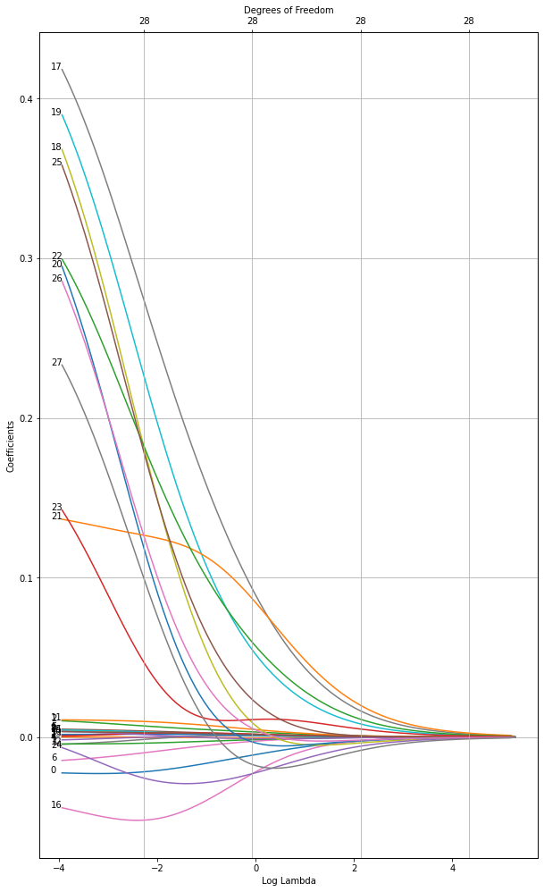

```
(-4.393752820140326, 5.737621589033473)
```

```python
from glmnetPlot import glmnetPlot
fig, ax = plt.subplots(figsize=(10, 17))
glmnetPlot(ridge_reg, xvar = 'lambda', label = True)
ax.get_xlim()
```

```python
train_predictor.columns
```

```
Index(['season', 'andy', 'angela', 'darryl', 'dwight', 'jim', 'kelly', 'kevin',
       'michael', 'oscar', 'pam', 'phyllis', 'ryan', 'toby', 'erin', 'jan',
       'ken_kwapis', 'greg_daniels', 'b_j_novak', 'paul_lieberstein',
       'mindy_kaling', 'paul_feig', 'gene_stupnitsky', 'jennifer_celotta',
       'randall_einhorn', 'brent_forrester', 'jeffrey_blitz',
       'justin_spitzer'],
      dtype='object')
```

```python
# lambda vs beta's

ridge_lambdaBeta_df = pd.DataFrame(columns=['lambda', 'beta'])
for i in range(ridge_reg['beta'].shape[1]):
  ridge_lambdaBeta_df = ridge_lambdaBeta_df.append(
      {'lambda': ridge_reg['lambdau'][i],
       'beta': {"beta"+str(j):ridge_reg['beta'].T[i, :][j] for j in range(ridge_reg['beta'].shape[0])}},
      ignore_index=True
  )
ridge_lambdaBeta_df = pd.merge(
    ridge_lambdaBeta_df,
    pd.json_normalize(ridge_lambdaBeta_df['beta']),
    left_index=True, right_index=True).drop(['beta'], axis = 1)
ridge_lambdaBeta_df = ridge_lambdaBeta_df.rename(columns={
    "beta"+str(i):train_predictor.columns[i] for i in range(ridge_reg['beta'].shape[0])
})
```

```python
# rank beta at a large lambda (10th largest lambda)
ridge_lambdaBeta_df.iloc[10,:].T[1:].apply(lambda beta: np.abs(beta)).sort_values(ascending=False)
```

```
paul_feig           0.002467
greg_daniels        0.001960
gene_stupnitsky     0.001354
justin_spitzer      0.001117
paul_lieberstein    0.000957
randall_einhorn     0.000719
jennifer_celotta    0.000695
b_j_novak           0.000548
season              0.000317
jeffrey_blitz       0.000295
mindy_kaling        0.000272
ken_kwapis          0.000202
phyllis             0.000107
angela              0.000092
kevin               0.000054
erin                0.000053
toby                0.000050
jim                 0.000047
jan                 0.000046
pam                 0.000044
ryan                0.000038
kelly               0.000033
michael             0.000033
dwight              0.000032
darryl              0.000023
oscar               0.000018
andy                0.000018
brent_forrester     0.000012
Name: 10, dtype: float64
```

```
(-0.02, 0.05)
```

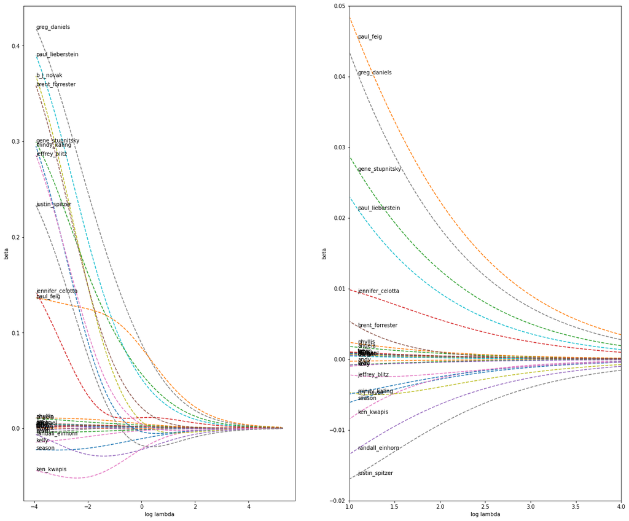

```python
fig, axs = plt.subplots(1, 2, figsize = (20,17))

ax = axs[0]
for col in train_predictor.columns:
  if col == 'lambda': pass
  x = np.log(ridge_lambdaBeta_df['lambda'])
  y = ridge_lambdaBeta_df[col]
  ax.plot(x, y, '--', label=col)
  ax.text(x[len(x)-1], y[len(x) - 1], col)
ax.set_xlabel('log lambda')
ax.set_ylabel('beta')

ax = axs[1]
for col in train_predictor.columns:
  if col == 'lambda': pass
  x = np.log(ridge_lambdaBeta_df['lambda'])
  y = ridge_lambdaBeta_df[col]
  ax.plot(x, y, '--', label=col)
  ax.text(x[len(x)-55], y[len(x)-55], col)
ax.set_xlabel('log lambda')
ax.set_ylabel('beta')
ax.set_xlim(left=1, right=4)
ax.set_ylim(bottom = -0.02, top=0.05)
```

The variable `paul_feig`, `greg_daniels`, `gene_stupnitsky`, and also `justin_spitzer` are the most important variables because even with high lambda value and therefore high penality on their regression coefficients, their reg coef. are the largest among the others.

#### Cross Validation to find a 'optimal' lambda

(The development of this glmnet wrapper seems to have ceased) so the rest of the assignment is on another rmd file.

```python
from cvglmnet import cvglmnet
# scipy functions deprecated
cv_ridge_reg = cvglmnet(x = train_predictor.to_numpy(), y = train_y.to_numpy(), family = "gaussian", alpha = 0, ptype = 'mse', nfolds = 10)
```

[output not shown]